# Stock Dynamics

##### *Unit-1: Introduction to Analytics*

A stock market is where buyers and sellers trade shares of a company, and is one of the most popular ways for individuals and companies to invest money. The size of the world stock market is now estimated to be in the trillions. The largest stock market in the world is the New York Stock Exchange (NYSE), located in New York City. About 2,800 companies are listed on the NYSE. In this problem, we’ll look at the monthly stock prices of five of these companies: [IBM](http://www.ibm.com/), [General Electric - GE](http://www.ge.com/), [Procter and Gamble](http://www.pg.com/), [Coca Cola](http://www.coca-cola.com/), and [Boeing](http://www.boeing.com/). The data used in this problem comes from [Infochimps](http://www.infochimps.com/).

Download and read the following files into R, using the read.csv function: IBMStock.csv, GEStock.csv, ProcterGambleStock.csv, CocaColaStock.csv, and BoeingStock.csv. Call the data frames “IBM”, “GE”, “ProcterGamble”, “CocaCola”, and “Boeing”, respectively.

```r
IBM = read.csv("IBMStock.csv")
GE = read.csv("GEStock.csv")
ProcterGamble = read.csv("ProcterGambleStock.csv")
CocaCola = read.csv("CocaColaStock.csv")
Boeing = read.csv("BoeingStock.csv")
```

Each data frame has two variables, described as follows:

- `Date`: the date of the stock price, always given as the first of the month.
- `StockPrice`: the average stock price of the company in the given month.

In this problem, we’ll take a look at how the stock dynamics of these companies have changed over time.

#### Summary Statistics

Before working with these data sets, we need to convert the dates into a format that R can understand. Take a look at the structure of one of the datasets using the str function. Right now, the date variable is stored as a factor. We can convert this to a “Date” object in R by using the following five commands (one for each data set):

```r
IBM$Date = as.Date(IBM$Date, "%m/%d/%y")
GE$Date = as.Date(GE$Date, "%m/%d/%y")
CocaCola$Date = as.Date(CocaCola$Date, "%m/%d/%y")
ProcterGamble$Date = as.Date(ProcterGamble$Date, "%m/%d/%y")
Boeing$Date = as.Date(Boeing$Date, "%m/%d/%y")
```

The first argument to the `as.Date` function is the variable we want to convert, and the second argument is the format of the Date variable. We can just overwrite the original Date variable values with the output of this function. Now, answer the following questions using the `str` and `summary` functions.

##### 1.1 How many observations are there in each data set (all have the same number of observations)?

```r
nrow(IBM)
```

```
## [1] 480
```

480 observations.

##### 1.2 What is the earliest year in our datasets?

```r
min(IBM$Date)
```

```
## [1] "1970-01-01"
```

##### 1.3 What is the latest year in our datasets?

```r
max(IBM$Date)
```

```
## [1] "2009-12-01"
```

##### 1.4 What is the mean stock price of IBM over this time period?

```r
mean(IBM$StockPrice)
```

```
## [1] 144.375
```

##### 1.5 What is the minimum stock price of General Electric (GE) over this time period?

```r
min(GE$StockPrice)
```

```
## [1] 9.293636
```

##### 1.6 What is the maximum stock price of Coca-Cola over this time period?

```r
max(CocaCola$StockPrice)
```

```
## [1] 146.5843
```

##### 1.7 What is the median stock price of Boeing over this time period?

```r
median(Boeing$StockPrice)
```

```
## [1] 44.8834
```

##### 1.8 What is the standard deviation of the stock price of Procter & Gamble over this time period?

```r
sd(ProcterGamble$StockPrice)
```

```
## [1] 18.19414
```

#### Visualizing Stock Dynamics

Let’s plot the stock prices to see if we can visualize trends in stock prices during this time period. Using the plot function, plot the Date on the x-axis and the StockPrice on the y-axis, for Coca-Cola.

This plots our observations as points, but we would really like to see a line instead, since this is a continuous time period. To do this, add the argument `type="l"` to your plot command, and re-generate the plot (the character is quotes is the letter l, for line). You should now see a line plot of the Coca-Cola stock price.

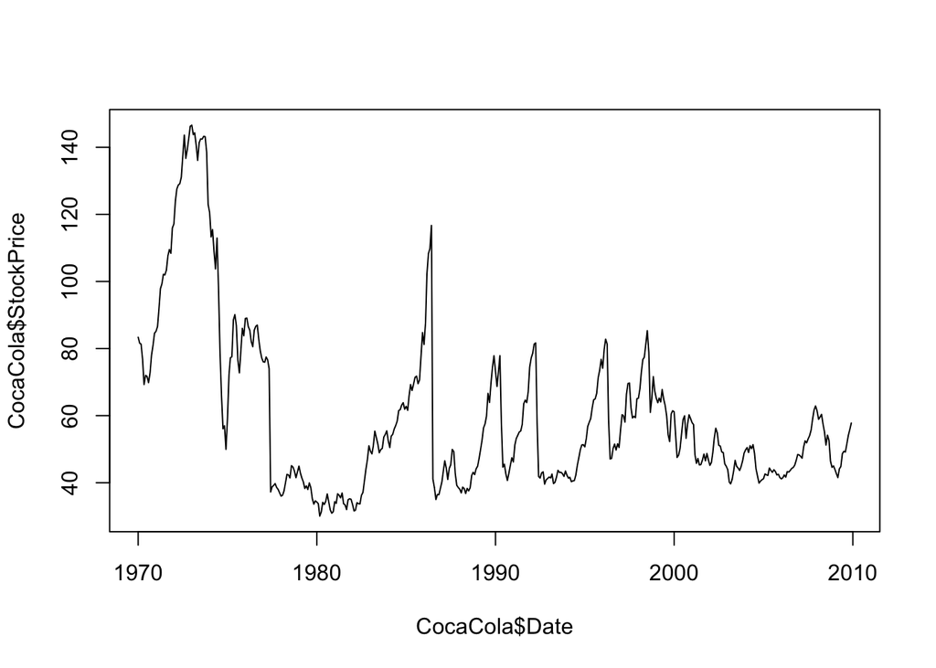

```r
plot(CocaCola$Date, CocaCola$StockPrice, type="l")
```

##### 2.1 Around what year did Coca-Cola has its highest and lowest stock price in this time period?

The above plot suggests that the highest was in 1973 and the lowest was in 1980.

##### 2.2 Which stock dropped more in the year 2000, during the technology bubble burst?

Now, let’s add the line for Procter & Gamble too. You can add a line to a plot in R by using the lines function instead of the plot function. Keeping the plot for Coca-Cola open, type in your R console:

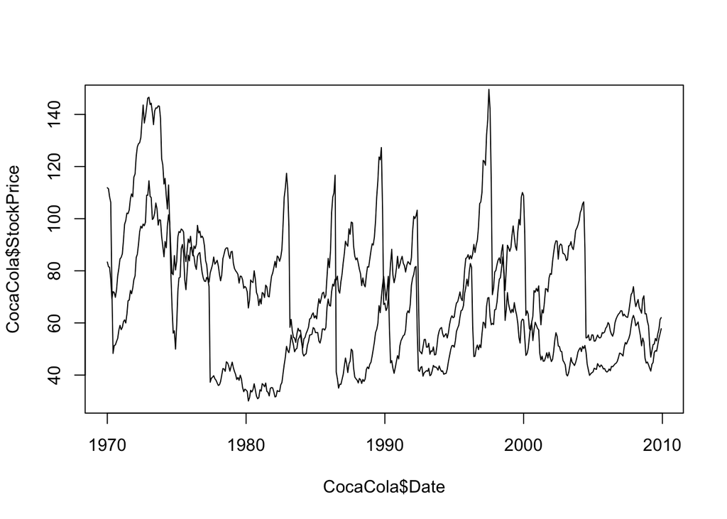

```r
plot(CocaCola$Date, CocaCola$StockPrice, type="l")
lines(ProcterGamble$Date, ProcterGamble$StockPrice)
```

Unfortunately, it’s hard to tell which line is which. Let’s fix this by giving each line a color. First, re-run the plot command for Coca-Cola, but add the argument `col="red"`. You should see the plot for Coca-Cola show up again, but this time in red. Now, let’s add the Procter & Gamble line (using the lines function like we did before), adding the argument `col="blue"`. You should now see in your plot the Coca-Cola stock price in red, and the Procter & Gamble stock price in blue.

As an alternative to changing the colors, you could instead change the line type of the Procter & Gamble line by adding the argument `lty=2`. This will make the Procter & Gamble line dashed.

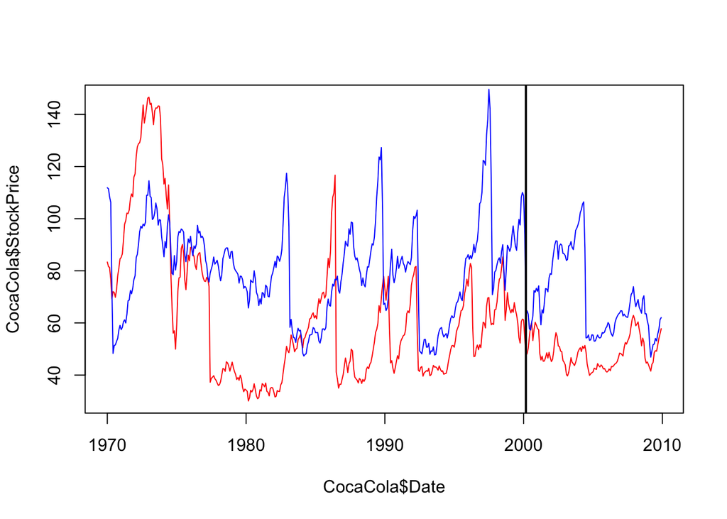

```r
plot(CocaCola$Date, CocaCola$StockPrice, type="l", col="red")
lines(ProcterGamble$Date, ProcterGamble$StockPrice, col="blue")
abline(v=as.Date(c("2000-03-01")), lwd=2)
```

**In March of 2000, the technology bubble burst, and a stock market crash** **occurred. According to this plot, which company’s stock dropped more?** Looking at the plot, around 2000, both stocks drop, but Procter and Gamble’s stock drops more.

##### 2.3 Around 1983, one of these stocks was going up, which one was it? Which stock generally had lower values?

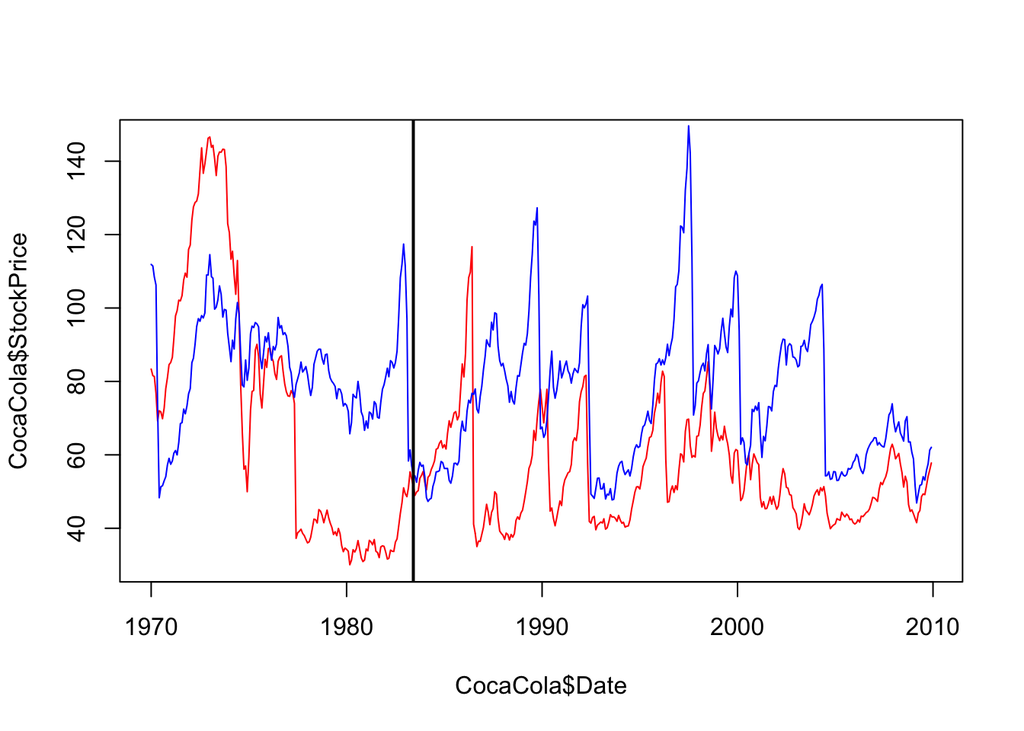

```r
plot(CocaCola$Date, CocaCola$StockPrice, type="l", col="red")
lines(ProcterGamble$Date, ProcterGamble$StockPrice, col="blue")
abline(v=as.Date(c("1983-06-01")), lwd=2)
```

From the plot, it can be noted that *Coca-Cola* has a slightly upward trend around 1983. It also generally has lower values than the Proctor Gamble stock.

#### Visualizing Stock Dynamics: 1995-2005

Let’s take a look at how the stock prices changed from 1995-2005 for all five companies. In your R console, start by typing the following plot command:

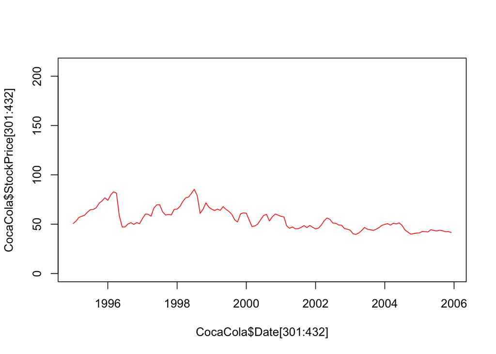

```r
plot(CocaCola$Date[301:432], CocaCola$StockPrice[301:432],
     type="l", col="red", ylim=c(0,210))
```

This will plot the CocaCola stock prices from 1995 through 2005, which are the observations numbered from 301 to 432. The additional argument, `ylim=c(0,210)`, makes the y-axis range from 0 to 210. This will allow us to see all of the stock values when we add in the other companies.

Now, use the lines function to add in the other four companies, remembering to only plot the observations from 1995 to 2005, or `[301:432]`. You don’t need the “type” or “ylim” arguments for the lines function, but remember to make each company a different color so that you can tell them apart. Some color options are “red”, “blue”, “green”, “purple”, “orange”, and “black”. To see all of the color options in R, type colors() in your R console.

*Use this plot to answer all of the questions in this problem.*

##### 3.1 Which stock fell the most right after the technology bubble burst in March 2000?

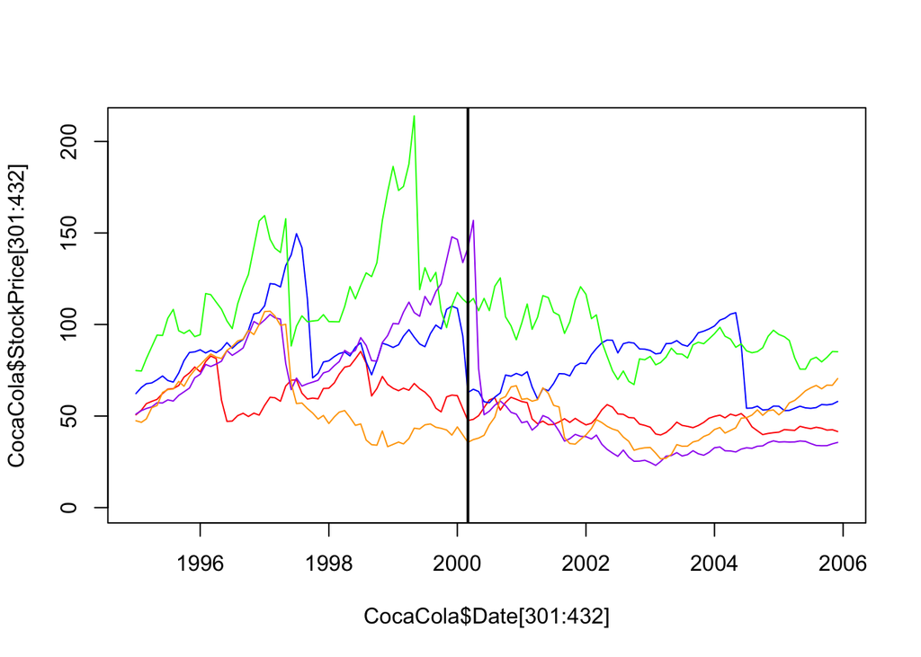

```r
plot(CocaCola$Date[301:432], CocaCola$StockPrice[301:432],
     type="l", col="red", ylim=c(0,210))
lines(ProcterGamble$Date[301:432], ProcterGamble$StockPrice[301:432], col="blue")
lines(IBM$Date[301:432], IBM$StockPrice[301:432], col="green")
lines(GE$Date[301:432], GE$StockPrice[301:432], col="purple")
lines(Boeing$Date[301:432], Boeing$StockPrice[301:432], col="orange")

abline(v=as.Date(c("2000-03-01")), lwd=2)
```

From this plot, it can been seen that the stock for General Electric falls significantly more than the other stocks after the technology bubble burst.

##### 3.2 Which stock reaches the highest value in the time period 1995-2005?

From the plot, it is seen that IBM has the value value, around 1999.

##### 3.3 Which companies saw a decreasing trend in their stock price during the economic crisis in Asia?

In October of 1997, there was a global stock market crash that was caused by an economic crisis in Asia. Comparing September 1997 to November 1997, which companies saw a decreasing trend in their stock price?

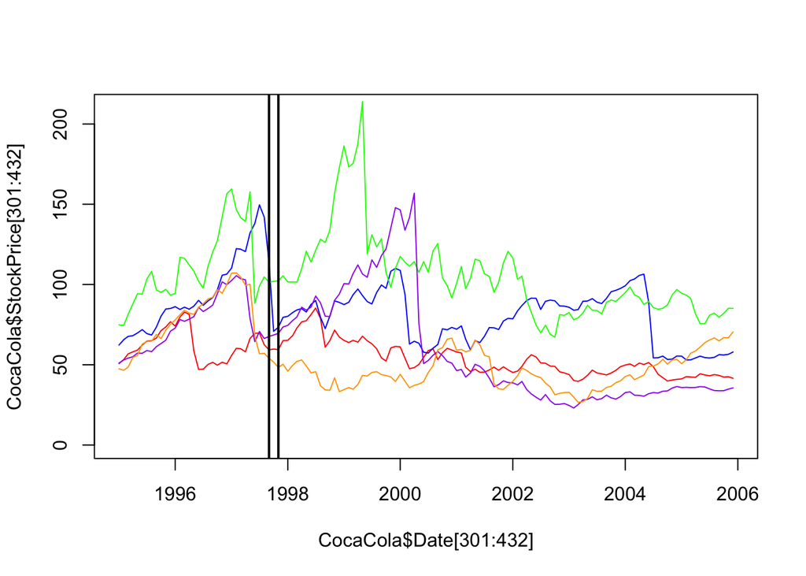

```r
plot(CocaCola$Date[301:432], CocaCola$StockPrice[301:432],
     type="l", col="red", ylim=c(0,210))
lines(ProcterGamble$Date[301:432], ProcterGamble$StockPrice[301:432], col="blue")
lines(IBM$Date[301:432], IBM$StockPrice[301:432], col="green")
lines(GE$Date[301:432], GE$StockPrice[301:432], col="purple")
lines(Boeing$Date[301:432], Boeing$StockPrice[301:432], col="orange")

abline(v=as.Date(c("1997-09-01")), lwd=2)
abline(v=as.Date(c("1997-11-01")), lwd=2)
```

From this plot, it can be noted that two companies had a decreasing trend in stock prices from September 1997 to November 1997: Boeing and Procter & Gamble.

##### 3.4 In the last two years of this time period (2004 & 2005), which stock seems to perform the best?

From the plot, it is seen that Boeing is steadily increasing from 2004 to beginning of 2006.

#### Monthly Trends

Lastly, let’s see if stocks tend to be higher or lower during certain months. Use the `tapply` command to calculate the mean stock price of IBM, sorted by months. To sort by months, use `months(IBM$Date)` as the second argument of `tapply` function.

For IBM, compare the monthly averages to overall average of the stock price.

##### 4.1 In which months has IBM historically had a higher stock price (on average)?

```r
mean(IBM$StockPrice)
```

```
## [1] 144.375
```

```r
tapply(IBM$StockPrice, months(IBM$Date), mean)
```

```
##     April    August  December  February   January      July      June
##  152.1168  140.1455  140.7593  152.6940  150.2384  139.0670  139.0907
##     March       May  November   October September
##  152.4327  151.5022  138.0187  137.3466  139.0885
```

Here it can is seen, that the price has been historically been higher than the average from January-May, and lower than average for the remaining months.

##### 4.2 General Electric and Coca-Cola both have their highest average stock price in which month?

```r
tapply(GE$StockPrice, months(GE$Date), mean)
```

```
##     April    August  December  February   January      July      June
##  64.48009  56.50315  59.10217  62.52080  62.04511  56.73349  56.46844
##     March       May  November   October September
##  63.15055  60.87135  57.28879  56.23897  56.23913
```

```r
tapply(CocaCola$StockPrice, months(CocaCola$Date), mean)
```

```
##     April    August  December  February   January      July      June
##  62.68888  58.88014  59.73223  60.73475  60.36849  58.98346  60.81208
##     March       May  November   October September
##  62.07135  61.44358  59.10268  57.93887  57.60024
```

General Electric has an average stock price of 64.48 in April, which is higher than any other month. Coca-Cola has an average stock price of 62.68 in April, which is higher than any other month.

##### 4.3 For the months of Dec/Jan, in which month are the average stock prices lower?

```r
tapply(IBM$StockPrice, months(IBM$Date), mean)
```

```
##     April    August  December  February   January      July      June
##  152.1168  140.1455  140.7593  152.6940  150.2384  139.0670  139.0907
##     March       May  November   October September
##  152.4327  151.5022  138.0187  137.3466  139.0885
```

```r
tapply(Boeing$StockPrice, months(Boeing$Date), mean)
```

```
##     April    August  December  February   January      July      June
##  47.04686  46.86311  46.17315  46.89223  46.51097  46.55360  47.38525
##     March       May  November   October September
##  46.88208  48.13716  45.14990  45.21603  46.30485
```

```r
tapply(ProcterGamble$StockPrice, months(ProcterGamble$Date), mean)
```

```
##     April    August  December  February   January      July      June
##  77.68671  76.82266  78.29661  79.02575  79.61798  76.64556  77.39275
##     March       May  November   October September
##  77.34761  77.85958  78.45610  76.67903  76.62385
```

```r
tapply(CocaCola$StockPrice, months(CocaCola$Date), mean)
```

```
##     April    August  December  February   January      July      June
##  62.68888  58.88014  59.73223  60.73475  60.36849  58.98346  60.81208
##     March       May  November   October September
##  62.07135  61.44358  59.10268  57.93887  57.60024
```

```r
tapply(GE$StockPrice, months(GE$Date), mean)
```

```
##     April    August  December  February   January      July      June
##  64.48009  56.50315  59.10217  62.52080  62.04511  56.73349  56.46844
##     March       May  November   October September
##  63.15055  60.87135  57.28879  56.23897  56.23913
```

It is a trend that the average price of the stock has been higher in January than December. The caveat here is that one really good or bad year could skew the average to show a trend that is not really there in general.

*End of Homework Assignment*